# TZ Gaming: Optimal Targeting of Mobile Ads

- Name: Shihan Wang
- GitLab id: “rsm-shw005”

## Setup

Please complete this Rmarkdown document by answering the questions in `tz-gaming.pdf` on Canvas (week5/). Create a Notebook/HTML file with all your results and comments and push both the Rmarkdown and HTML file to GitLab when you are done. All results MUST be reproducible (i.e., the TA and I must be able to recreate the HTML from the Rmarkdown file without changes or errors).

> Note: If you use Rstudio’s git tab to push your submission to GitLab you may see warnings or messages when pushing the HTML file because of its size. To avoid these messages you can also push your files to GitLab by using GitGadget’s “Sync” tab (i.e., Commit your changes and then Push).

```r
## loading the data - this dataset must NOT be changed
tz_gaming <- readr::read_rds("data/tz_gaming.rds")
radiant.data::describe(tz_gaming)
```

[output not shown]

## Question answers

Part I: Logistic Regression (10 points)

1. Estimate a logistic regression model using click as the response variable and the following as explanatory variables:

impup, clup, ctrup, impua, clua, ctrua, imput, clut, ctrut, imppat, clpat The model should predict the probability of click == “yes”. Seehttps://radiant-rstats.github.io/docs/model/logistic.html and http://radiant-rstats.github.io/radiant.model/reference/logistic.html for details. Create a new variable called click_logit with the predicted click-through probability linked to each impression. You can, of course, also use the glm function in R but you will have to do more work to get all the required output. In python you can use import statsmodels.formula.api as smf and then smf.logit to estimate the model.

```r
result <- logistic(
  tz_gaming,
  rvar = "click",
  evar = c(
    "impup", "clup", "ctrup", "impua", "clua", "ctrua", "imput",
    "clut", "ctrut", "imppat", "clpat", "ctrpat"
  ),
  lev = "yes",
  data_filter = "training == 'train'"
)
summary(result)
```

```
Logistic regression (GLM)
Data                 : tz_gaming
Filter               : training == 'train'
Response variable    : click
Level                : yes in click
Explanatory variables: impup, clup, ctrup, impua, clua, ctrua, imput, clut, ctrut, imppat, clpat, ctrpat
Null hyp.: there is no effect of x on click
Alt. hyp.: there is an effect of x on click

                OR coefficient std.error z.value p.value
 (Intercept)            -4.963     0.087 -56.843  < .001 ***
 impup       1.000       0.000     0.000   0.324   0.746
 clup        1.010       0.010     0.004   2.743   0.006 **
 ctrup       1.030       0.030     0.004   6.915  < .001 ***
 impua       0.986      -0.014     0.002  -5.920  < .001 ***
 clua        1.046       0.045     0.070   0.635   0.525
 ctrua       1.008       0.008     0.003   2.754   0.006 **
 imput       0.995      -0.005     0.001  -4.182  < .001 ***
 clut        1.254       0.226     0.021  10.582  < .001 ***
 ctrut       1.031       0.030     0.003   9.233  < .001 ***
 imppat      1.000      -0.000     0.000  -3.583  < .001 ***
 clpat       1.001       0.001     0.000   4.331  < .001 ***
 ctrpat      1.359       0.307     0.039   7.820  < .001 ***

Signif. codes:  0 '***' 0.001 '**' 0.01 '*' 0.05 '.' 0.1 ' ' 1

Pseudo R-squared: 0.147
Log-likelihood: -3780.032, AIC: 7586.063, BIC: 7708.001
Chi-squared: 1300.361 df(12), p.value < .001
Nr obs: 87,535
```

```r
pred <- predict(result, pred_data = tz_gaming)
print(pred, n = 10)
```

```
Logistic regression (GLM)
Data                 : tz_gaming
Filter               : training == 'train'
Response variable    : click
Level(s)             : yes in click
Explanatory variables: impup, clup, ctrup, impua, clua, ctrua, imput, clut, ctrut, imppat, clpat, ctrpat
Interval             : confidence
Prediction dataset   : tz_gaming
Rows shown           : 10 of 115,488

 impup clup ctrup impua clua ctrua imput clut  ctrut imppat clpat ctrpat Prediction  2.5% 97.5%
   439    2 0.456     2    0 0.000    25    0  0.000     71     1  1.408      0.010 0.009 0.011
    64    0 0.000     5    0 0.000     7    0  0.000  67312  1069  1.588      0.016 0.014 0.018
    80    0 0.000    76    5 6.579    94    0  0.000    331     1  0.302      0.002 0.001 0.004
    25    0 0.000    10    0 0.000    19    0  0.000  71114  1001  1.408      0.011 0.010 0.013
  3834   29 0.756   145    1 0.690   329    4  1.216 183852  2317  1.260      0.002 0.001 0.003
   797    4 0.502    31    1 3.226    59    1  1.695    984     5  0.508      0.006 0.005 0.007
   686    4 0.583    20    0 0.000    36    0  0.000  18897   196  1.037      0.006 0.006 0.007
  1443    8 0.554    43    1 2.326    64    0  0.000    984     5  0.508      0.004 0.003 0.005
  2161    4 0.185   152    0 0.000   109    1  0.917  36317   514  1.415      0.001 0.001 0.002
   256    1 0.391    17    0 0.000     7    1 14.286  77884  1201  1.542      0.027 0.023 0.031
```

```r
tz_gaming <- store(tz_gaming, pred, name = "click_logit")
```

2. Summarize and interpret the logistic regression results. Which explanatory variables are statistically signiﬁcant? Which variables seem to be most “important”? Make sure your model evaluation includes (1) an interpretation of the odds-ratios estimated for each of the explanatory variables and (2) an evaluation of the model as a whole.

1. Clut: One more impression the user has clicked on in the hour increases the odds of click by a factor of 1.254 (or 25.4%).

Ctrpat: One percent increase in click-through rate of the TZ ad in the app in the hour increases the odds of click by a factor of 1.359 (or 35.9%).

2. Overall, the logistic regression model explains 14.7% of variation in probability of clicking ad. The overall p value is less than 0.001, indicating that this is a solid model in predicting the probability of clicking.

Part II: Decile Analysis of Logistic Regression Results (10 points) Note: For the following questions, use only the “test” sample of impressions (i.e., 27,953 rows where “training == ‘test’”)

1. Assign each impression to a decile based on the predicted probability of click through. Create a new variable dec_logit that captures this information. Note: The ﬁrst decile should have the highest average click-through rate. If not, make sure to “reverse” the decile numbers (i.e., 10 becomes 1, 9 becomes 2, etc.). Please use the xtile function to create the deciles.

```r
## bin variables

test <- tz_gaming %>%
  filter(training == "test") %>%
  mutate(dec_logit = xtile(click_logit, 10, rev = TRUE))
```

2. Create a bar chart of click-through rates per decile (i.e., use dec_logit as the x-variable and click == “yes” as the y-variable). Note that the “click through rate” is not the same as the “predicted probability of click.” The click through rate captures the proportion of impressions in a given group (e.g., in a decile) that actually resulted in a click.

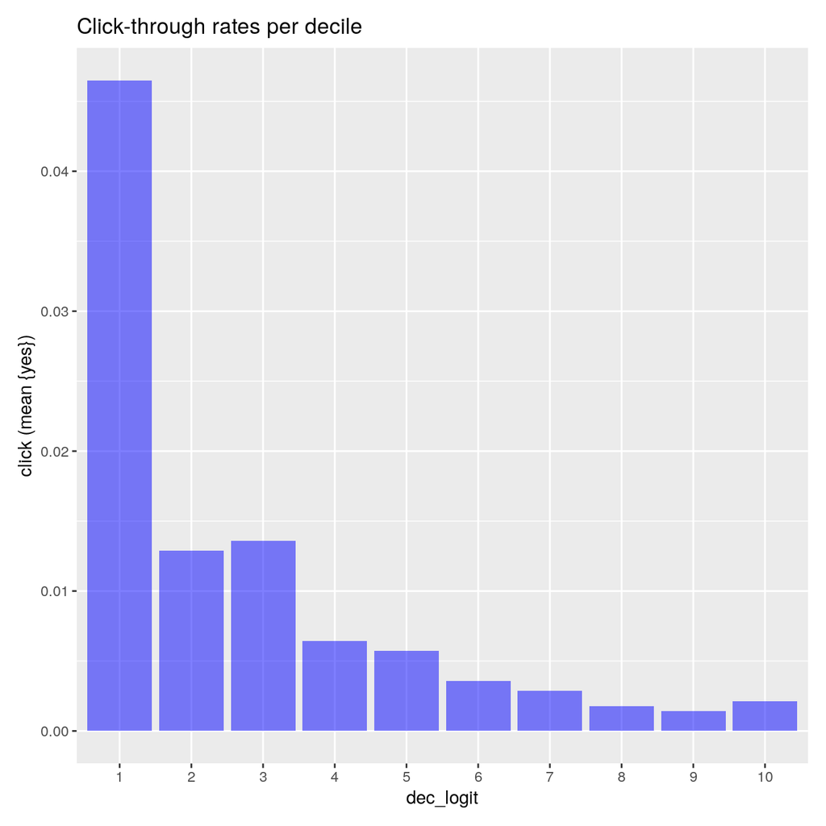

```r
visualize(
  test,
  xvar = "dec_logit",
  yvar = "click",
  type = "bar",
  labs = list(title = "Click-through rates per decile"),
  custom = FALSE
)
```

3. Report the number of impressions, the number of clicks, and the click-through rate for the TZ ad per decile and save this information to a dataframe. Use the name dec_df_logit for the new data frame.

```r
dec_df_logit <- test %>%
  group_by(dec_logit) %>%
  summarise(
    number_of_impressions = n(),
    number_of_clicks = sum(click == "yes"),
    click_through_rate = number_of_clicks / number_of_impressions
  )
dec_df_logit
```

```
# A tibble: 10 x 4
   dec_logit number_of_impressions number_of_clicks click_through_rate
       <int>                 <int>            <int>              <dbl>
 1         1                  2796              130            0.0465
 2         2                  2795               36            0.0129
 3         3                  2795               38            0.0136
 4         4                  2795               18            0.00644
 5         5                  2795               16            0.00572
 6         6                  2796               10            0.00358
 7         7                  2795                8            0.00286
 8         8                  2795                5            0.00179
 9         9                  2795                4            0.00143
10        10                  2796                6            0.00215
```

4. Estimate a logistic regression model with click as the response variable and imppat, clpat, and ctrpat as the only explanatory variable. Make sure to “standardize” the explanatory variables before estimation. What is the interpretation of the standardized odds-ratios for the explanatory variables?

imppat: 1 more impression that showed the TZ ad in the app in the hour will decrease the odds of clicking by a factor of 0.134

clpat: 1 more click the TZ ad has received in the app in the hour will increase the odds of clickng by a factor of 11.688

ctrpat: 1 percent increase of past click through rate will increase the odds of clicking by a factor of 2.025

```r
result2 <- logistic(
  tz_gaming,
  rvar = "click",
  evar = c("imppat", "clpat", "ctrpat"),
  lev = "yes",
  check = "standardize",
  data_filter = "training == 'train'"
)
summary(result2)
```

```
Logistic regression (GLM)
Data                 : tz_gaming
Filter               : training == 'train'
Response variable    : click
Level                : yes in click
Explanatory variables: imppat, clpat, ctrpat
Null hyp.: there is no effect of x on click
Alt. hyp.: there is an effect of x on click
**Standardized odds-ratios and coefficients shown (2 X SD)**

                 OR coefficient std.error  z.value p.value
 (Intercept)             -4.915     0.043 -114.229  < .001 ***
 imppat       0.134      -2.010     0.419   -4.802  < .001 ***
 clpat       11.688       2.459     0.430    5.713  < .001 ***
 ctrpat       2.025       0.705     0.051   13.933  < .001 ***

Signif. codes:  0 '***' 0.001 '**' 0.01 '*' 0.05 '.' 0.1 ' ' 1

Pseudo R-squared: 0.035
Log-likelihood: -4273.088, AIC: 8554.176, BIC: 8591.695
Chi-squared: 314.248 df(3), p.value < .001
Nr obs: 87,535
```

5. Some of the variables in the dataset are highly correlated with each other. In particular, imppat and clpat have a positive correlation of 0.97. Discuss the implications of this (very) high level of collinearity and also diﬀerent approaches to deal with it. What are the implications for the model and the interpretation of the estimated (standardized) coeﬃcients? As part of your answer, discuss the change in the estimated (standardized) odd-ratio for imppat when you remove clpat from the model.

High level of collinearity can increase the variance of the coefficient estimates and make the estimates very sensitive to minor changes in the model. As a result, the coefficient estimates are unstable and difficult to interpret.

Approach: Stepwise check, correlation table.

1 more impression that showed the TZ ad in the app in the hour will increase the odds of clicking by a factor of 1.412

```r
result3 <- logistic(
  tz_gaming,
  rvar = "click",
  evar = c("imppat", "ctrpat"),
  lev = "yes",
  check = "standardize",
  data_filter = "training == 'train'"
)
summary(result3)
```

```
Logistic regression (GLM)
Data                 : tz_gaming
Filter               : training == 'train'
Response variable    : click
Level                : yes in click
Explanatory variables: imppat, ctrpat
Null hyp.: there is no effect of x on click
Alt. hyp.: there is an effect of x on click
**Standardized odds-ratios and coefficients shown (2 X SD)**

                OR coefficient std.error  z.value p.value
 (Intercept)            -4.859     0.040 -121.262  < .001 ***
 imppat      1.412       0.345     0.063    5.460  < .001 ***
 ctrpat      2.246       0.809     0.044   18.422  < .001 ***

Signif. codes:  0 '***' 0.001 '**' 0.01 '*' 0.05 '.' 0.1 ' ' 1

Pseudo R-squared: 0.031
Log-likelihood: -4290.903, AIC: 8587.805, BIC: 8615.945
Chi-squared: 278.619 df(2), p.value < .001
Nr obs: 87,535
```

6. Estimate another logistic regression model with click as the response variable and time_fct, app, imppat, clpat, and ctrpat as the explanatory variable. Why are the odds ratios for imppat, clpat, and ctrpat diﬀerent in the two models? Please be speciﬁc and investigate beyond simply stating the statistical problem.

In the second model, the effect of all three variales are decreased, which means the positive effects become less positive and the negative effect becomes less negative as well. It is because that part of effect of these three variales are explained by the app and time-fct variables.

```r
result4 <- logistic(
  tz_gaming,
  rvar = "click",
  evar = c("time_fct", "app", "imppat", "clpat", "ctrpat"),
  lev = "yes",
  check = "standardize",
  data_filter = "training == 'train'"
)
summary(result4)
```

```
Logistic regression (GLM)
Data                 : tz_gaming
Filter               : training == 'train'
Response variable    : click
Level                : yes in click
Explanatory variables: time_fct, app, imppat, clpat, ctrpat
Null hyp.: there is no effect of x on click
Alt. hyp.: there is an effect of x on click
**Standardized odds-ratios and coefficients shown (2 X SD)**

                OR coefficient std.error z.value p.value
 (Intercept)            -4.387     0.206 -21.281  < .001 ***
 time_fct|2  0.588      -0.532     0.323  -1.644   0.100
 time_fct|3  0.693      -0.367     0.461  -0.795   0.426
 time_fct|4  0.000     -14.834   487.743  -0.030   0.976
 time_fct|5  0.000     -14.860   635.984  -0.023   0.981
 time_fct|6  0.359      -1.025     1.027  -0.999   0.318
 time_fct|7  1.220       0.199     0.438   0.453   0.650
 time_fct|8  1.135       0.127     0.309   0.411   0.681
 time_fct|9  1.063       0.061     0.299   0.203   0.839
 time_fct|10 0.843      -0.170     0.303  -0.561   0.575
 time_fct|11 0.637      -0.451     0.288  -1.565   0.118
 time_fct|12 0.834      -0.181     0.292  -0.620   0.535
 time_fct|13 0.535      -0.626     0.306  -2.047   0.041 *
 time_fct|14 0.982      -0.018     0.257  -0.069   0.945
 time_fct|15 0.840      -0.174     0.272  -0.639   0.523
 time_fct|16 0.874      -0.135     0.279  -0.483   0.629
 time_fct|17 0.864      -0.146     0.296  -0.493   0.622
 time_fct|18 0.942      -0.060     0.286  -0.208   0.835
 time_fct|19 1.178       0.164     0.251   0.651   0.515
 time_fct|20 1.188       0.172     0.247   0.698   0.485
 time_fct|21 0.782      -0.245     0.261  -0.942   0.346
 time_fct|22 0.933      -0.069     0.259  -0.267   0.789
 time_fct|23 0.993      -0.007     0.268  -0.025   0.980
 time_fct|24 1.134       0.125     0.258   0.486   0.627
 app|app2    0.136      -1.997     0.351  -5.681  < .001 ***
 app|app3    0.187      -1.675     1.016  -1.649   0.099 .
 app|app4    0.487      -0.719     0.359  -2.004   0.045 *
 app|app5    0.413      -0.883     1.011  -0.874   0.382
 app|app6    1.007       0.007     0.216   0.034   0.973
```

[output cut: 38 more lines]

```
 app|app45   1.920       0.652     0.604   1.079   0.281
 app|app46   0.466      -0.763     1.020  -0.748   0.455
 app|app47   0.406      -0.902     1.012  -0.891   0.373
 app|app48   0.000     -15.045  1178.615  -0.013   0.990
 app|app49   0.259      -1.349     1.019  -1.324   0.185
 imppat      0.365      -1.008     0.891  -1.131   0.258
 clpat       2.934       1.076     0.948   1.135   0.256
 ctrpat      1.116       0.110     0.172   0.637   0.524

Signif. codes:  0 '***' 0.001 '**' 0.01 '*' 0.05 '.' 0.1 ' ' 1

Pseudo R-squared: 0.056
Log-likelihood: -4180.646, AIC: 8511.292, BIC: 9214.776
Chi-squared: 499.132 df(74), p.value < .001
Nr obs: 87,535
```

Part III: Lift and Gains (5 points) Note: For the following questions, use only the “test” sample of impressions (i.e., 27,953 rows where “training == ‘test’”)

1. Use the data frame you created in II.c above to generate a table with lift and cumulative lift numbers for each decile

```r
overall_click_through_rate <- sum(dec_df_logit$number_of_clicks) / sum(dec_df_logit$number_of_impressions)
dec_df_logit <- dec_df_logit %>%
  mutate(lift = click_through_rate / {{ overall_click_through_rate }}) %>%
  mutate(
    cum_impressions = cumsum(number_of_impressions),
    cum_clicks = cumsum(number_of_clicks),
    cum_click_rate = cum_clicks / cum_impressions,
    cum_lift = cum_click_rate / {{ overall_click_through_rate }}
  )
```

2. Create a ggplot (or matplotlib or altair) chart showing the cumulative lift per decile

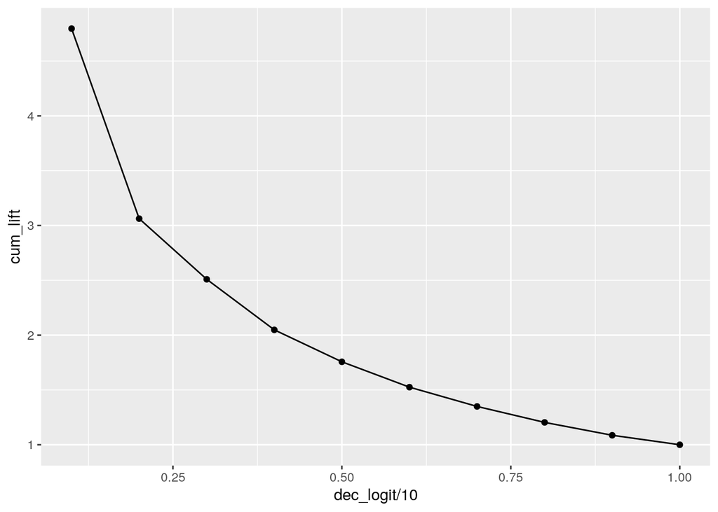

```r
ggplot(dec_df_logit, aes(dec_logit / 10, cum_lift)) + geom_point() + geom_line()
```

3. Use the data frame you created in II.c above to generate a table with gains and cumulative gains numbers for each decile

```r
overall_click <- sum(dec_df_logit$number_of_clicks)

dec_df_logit <- dec_df_logit %>%
  mutate(
    gains = number_of_clicks / {{ overall_click }},
    cum_gains = cum_clicks / {{ overall_click }}
  )
```

4. Create a ggplot (or matplotlib or altair) chart showing the cumulative gains per decile along with a reference line for the “no model” Note: Do not use any specialized packages to construct the lift and gains tables and charts

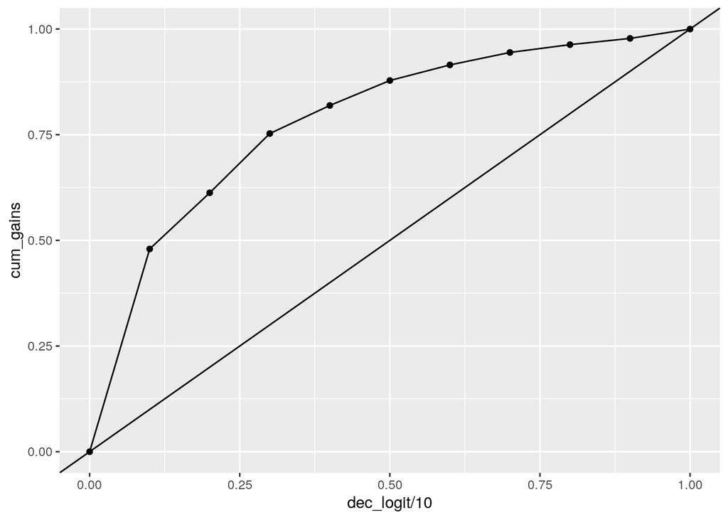

```r
dec_df_logit1 <- rbind(dec_df_logit, c(0, 0, 0, 0, 0, 0, 0, 0, 0, 0, 0))
ggplot(dec_df_logit1, aes(dec_logit/10, cum_gains)) + geom_point() + geom_line() + geom_abline(intercept = 0, slope = 1)
```

Part IV: Confusion matrix (5 points)

1. Create a “confusion matrix” based on the predictions from the logistic regression model you estimated above for I.a. Again, use only data from the test set here(i.e., “training==‘test’”). Use the ﬁnancial assumptions mentioned above, and repeated in section V below, to determine an appropriate cutoﬀ. Calculate “accuracy” based on the confusion matrix you created (see http://lab.rady.ucsd.edu/ sawtooth/RBusinessAnalytics/logit_models.html for an example using R). Note: Do not use any specialized packages to construct the confusion matrix

```r
## confusion matrix for Model I.a

cpm <- 10 / 1000
conversion <- 0.05
clv <- 25

breakeven <- cpm / (clv * conversion)
breakeven
```

```
[1] 0.008
```

```r
threshold <- breakeven
df1 <- test %>%
  mutate(Pred.Click = click_logit > threshold)
df1
```

```
# A tibble: 27,953 x 25
   training inum    click  time time_fct app   id       impup  clup ctrup impua  clua ctrua imput  clut ctrut imppat clpat ctrpat     rnd click_vneta click_logit_step_pre click_logit dec_logit Pred.Click
   <chr>    <chr>   <fct> <int> <fct>    <fct> <chr>    <int> <int> <dbl> <int> <int> <dbl> <int> <int> <dbl>  <int> <int>  <dbl>   <dbl>       <dbl>                <dbl>       <dbl>     <int> <lgl>
 1 test     I300002 no       21 21       app1  id466983  1458     3 0.206    42     0     0    66     0 0      68113   957  1.41   0.148      0.00396            0.00672     0.00626           5 FALSE
 2 test     I300006 no        3 3        app40 id946375     3     0 0         4     0     0     1     0 0         50     0  0      0.383      0.0190             0.0147      0.00654           5 FALSE
 3 test     I300012 no        5 5        app12 id479295  5057     6 0.119   186     0     0   734     0 0        754     8  1.06   1.27       0.00396            0.0000532   0.0000281        10 FALSE
 4 test     I300015 no       10 10       app1  id83284   1993    10 0.502    63     0     0   139     0 0      26537   276  1.04   0.673      0.00396            0.00372     0.00239           8 FALSE
 5 test     I300016 no       14 14       app1  id359434   212     7 3.30      7     0     0    19     1 5.26   57348   874  1.52  -0.786      0.0507             0.0222      0.0221            1 TRUE
 6 test     I300020 no       23 23       app37 id628151    21     0 0         4     0     0     7     0 0       1025     5  0.488 -0.0476     0.0190             0.00607     0.00731           5 FALSE
 7 test     I300025 no       23 23       app4  id237946    36     1 2.78      3     0     0     4     0 0       6702    39  0.582 -0.449      0.0190             0.00853     0.00812           4 TRUE
 8 test     I300027 no       18 18       app1  id500964  1788     9 0.503    86     0     0   127     1 0.787  77884  1201  1.54  -0.939      0.00396            0.00402     0.00451           7 FALSE
 9 test     I300028 no       14 14       app1  id837018   999     3 0.300    54     0     0    62     0 0      57348   874  1.52   0.276      0.00396            0.00596     0.00588           6 FALSE
10 test     I300040 no       20 20       app1  id749091   200     3 1.5       5     0     0    16     0 0      42763   584  1.37  -0.391      0.00396            0.0141      0.0114            2 TRUE
# … with 27,943 more rows
```

```r
conf.mat1 <- table(df1$click, df1$Pred.Click)
conf.mat1
```

```
      FALSE  TRUE
  yes    58   213
  no  17984  9698
```

```r
acc1 <- (conf.mat1[1, 2] + conf.mat1[2, 1]) / sum(conf.mat1)
cat("Model Accuracy=", acc1)
```

```
Model Accuracy= 0.6509856
```

2. Calculate a confusion matrix based on predictions from a logistic regression with click as the response variable and rnd as the only explanatory variable. As before, the model should be estimated on training sample (i.e., “training == ‘train’”). Generate predictions for all rows in the data and create the confusion matrix based only on the test set (i.e., “training == ‘train’”). Calculate “accuracy” based on the confusion matrix you created.

```r
result5 <- logistic(
  tz_gaming,
  rvar = "click",
  evar = c("rnd"),
  lev = "yes",
  data_filter = "training == 'train'"
)
summary(result5)
```

```
Logistic regression (GLM)
Data                 : tz_gaming
Filter               : training == 'train'
Response variable    : click
Level                : yes in click
Explanatory variables: rnd
Null hyp.: there is no effect of rnd on click
Alt. hyp.: there is an effect of rnd on click

                OR coefficient std.error  z.value p.value
 (Intercept)            -4.720     0.036 -130.660  < .001 ***
 rnd         0.965      -0.036     0.036   -0.986   0.324

Signif. codes:  0 '***' 0.001 '**' 0.01 '*' 0.05 '.' 0.1 ' ' 1

Pseudo R-squared: 0
Log-likelihood: -4429.726, AIC: 8863.451, BIC: 8882.211
Chi-squared: 0.973 df(1), p.value 0.324
Nr obs: 87,535
```

```r
pred5 <- predict(result5, pred_data = test)
print(pred5, n = 10)
```

```
Logistic regression (GLM)
Data                 : tz_gaming
Filter               : training == 'train'
Response variable    : click
Level(s)             : yes in click
Explanatory variables: rnd
Interval             : confidence
Prediction dataset   : test
Rows shown           : 10 of 27,953

    rnd Prediction  2.5% 97.5%
  0.148      0.009 0.008 0.009
  0.383      0.009 0.008 0.009
  1.274      0.008 0.008 0.009
  0.673      0.009 0.008 0.009
 -0.786      0.009 0.008 0.010
 -0.048      0.009 0.008 0.009
 -0.449      0.009 0.008 0.010
 -0.939      0.009 0.008 0.010
  0.276      0.009 0.008 0.009
 -0.391      0.009 0.008 0.010
```

```r
test <- store(test, pred5, name = "click_logit_5")


df2 <- test %>%
  mutate(Pred.Click_5 = click_logit_5 > threshold)
df2
```

```
# A tibble: 27,953 x 26
   training inum    click  time time_fct app   id       impup  clup ctrup impua  clua ctrua imput  clut ctrut imppat clpat ctrpat     rnd click_vneta click_logit_step_pre click_logit dec_logit click_logit_5 Pred.Click_5
   <chr>    <chr>   <fct> <int> <fct>    <fct> <chr>    <int> <int> <dbl> <int> <int> <dbl> <int> <int> <dbl>  <int> <int>  <dbl>   <dbl>       <dbl>                <dbl>       <dbl>     <int>         <dbl> <lgl>
 1 test     I300002 no       21 21       app1  id466983  1458     3 0.206    42     0     0    66     0 0      68113   957  1.41   0.148      0.00396            0.00672     0.00626           5       0.00879 TRUE
 2 test     I300006 no        3 3        app40 id946375     3     0 0         4     0     0     1     0 0         50     0  0      0.383      0.0190             0.0147      0.00654           5       0.00872 TRUE
 3 test     I300012 no        5 5        app12 id479295  5057     6 0.119   186     0     0   734     0 0        754     8  1.06   1.27       0.00396            0.0000532   0.0000281        10       0.00845 TRUE
 4 test     I300015 no       10 10       app1  id83284   1993    10 0.502    63     0     0   139     0 0      26537   276  1.04   0.673      0.00396            0.00372     0.00239           8       0.00863 TRUE
 5 test     I300016 no       14 14       app1  id359434   212     7 3.30      7     0     0    19     1 5.26   57348   874  1.52  -0.786      0.0507             0.0222      0.0221            1       0.00909 TRUE
 6 test     I300020 no       23 23       app37 id628151    21     0 0         4     0     0     7     0 0       1025     5  0.488 -0.0476     0.0190             0.00607     0.00731           5       0.00885 TRUE
 7 test     I300025 no       23 23       app4  id237946    36     1 2.78      3     0     0     4     0 0       6702    39  0.582 -0.449      0.0190             0.00853     0.00812           4       0.00898 TRUE
 8 test     I300027 no       18 18       app1  id500964  1788     9 0.503    86     0     0   127     1 0.787  77884  1201  1.54  -0.939      0.00396            0.00402     0.00451           7       0.00914 TRUE
 9 test     I300028 no       14 14       app1  id837018   999     3 0.300    54     0     0    62     0 0      57348   874  1.52   0.276      0.00396            0.00596     0.00588           6       0.00875 TRUE
10 test     I300040 no       20 20       app1  id749091   200     3 1.5       5     0     0    16     0 0      42763   584  1.37  -0.391      0.00396            0.0141      0.0114            2       0.00896 TRUE
# … with 27,943 more rows
```

```r
conf.mat2 <- table(df2$click, df2$Pred.Click_5)
conf.mat2
```

```
      FALSE  TRUE
  yes     0   271
  no     76 27606
```

```r
acc2 <- (conf.mat2[1, 2] + conf.mat2[2, 1]) / sum(conf.mat2)
cat("Model Accuracy=", acc2)
```

```
Model Accuracy= 0.01241369
```

3. Discuss the similarities and diﬀerences between the two confusion matrices. Which model is best based on the confusion matrix? Provide support for your conclusions.

Difference: No FN for second matrix. First matrix has much fewer FP while much more TN. First matrix is much more accurate. Similarities: Similar number of TP. Based on the accuracy, first logistic regression model is better.

4. Recalculate the confusion matrices from IV.a and IV.b using 0.5 as the cutoﬀ. Based on these new matrices, discuss again the similarities and diﬀerences. Which model is best based on the confusion matrix? Provide support for your conclusions.

Difference: No TP and FP for second model. Similarities: Similar accuracy, similar number of TN and FN. Based on the accuracy of these 2 matrices, second model is better.

```r
df3 <- test %>%
  mutate(Pred.Click1 = click_logit > 0.5)
df3
```

```
# A tibble: 27,953 x 26
   training inum    click  time time_fct app   id       impup  clup ctrup impua  clua ctrua imput  clut ctrut imppat clpat ctrpat     rnd click_vneta click_logit_step_pre click_logit dec_logit click_logit_5 Pred.Click1
   <chr>    <chr>   <fct> <int> <fct>    <fct> <chr>    <int> <int> <dbl> <int> <int> <dbl> <int> <int> <dbl>  <int> <int>  <dbl>   <dbl>       <dbl>                <dbl>       <dbl>     <int>         <dbl> <lgl>
 1 test     I300002 no       21 21       app1  id466983  1458     3 0.206    42     0     0    66     0 0      68113   957  1.41   0.148      0.00396            0.00672     0.00626           5       0.00879 FALSE
 2 test     I300006 no        3 3        app40 id946375     3     0 0         4     0     0     1     0 0         50     0  0      0.383      0.0190             0.0147      0.00654           5       0.00872 FALSE
 3 test     I300012 no        5 5        app12 id479295  5057     6 0.119   186     0     0   734     0 0        754     8  1.06   1.27       0.00396            0.0000532   0.0000281        10       0.00845 FALSE
 4 test     I300015 no       10 10       app1  id83284   1993    10 0.502    63     0     0   139     0 0      26537   276  1.04   0.673      0.00396            0.00372     0.00239           8       0.00863 FALSE
 5 test     I300016 no       14 14       app1  id359434   212     7 3.30      7     0     0    19     1 5.26   57348   874  1.52  -0.786      0.0507             0.0222      0.0221            1       0.00909 FALSE
 6 test     I300020 no       23 23       app37 id628151    21     0 0         4     0     0     7     0 0       1025     5  0.488 -0.0476     0.0190             0.00607     0.00731           5       0.00885 FALSE
 7 test     I300025 no       23 23       app4  id237946    36     1 2.78      3     0     0     4     0 0       6702    39  0.582 -0.449      0.0190             0.00853     0.00812           4       0.00898 FALSE
 8 test     I300027 no       18 18       app1  id500964  1788     9 0.503    86     0     0   127     1 0.787  77884  1201  1.54  -0.939      0.00396            0.00402     0.00451           7       0.00914 FALSE
 9 test     I300028 no       14 14       app1  id837018   999     3 0.300    54     0     0    62     0 0      57348   874  1.52   0.276      0.00396            0.00596     0.00588           6       0.00875 FALSE
10 test     I300040 no       20 20       app1  id749091   200     3 1.5       5     0     0    16     0 0      42763   584  1.37  -0.391      0.00396            0.0141      0.0114            2       0.00896 FALSE
# … with 27,943 more rows
```

```r
conf.mat3 <- table(df3$click, df3$Pred.Click1)
conf.mat3
```

```
      FALSE  TRUE
  yes   262     9
  no  27661    21
```

```r
acc3 <- (conf.mat3[1, 2] + conf.mat3[2, 1]) / sum(conf.mat3)
cat("Model Accuracy=", acc3)
```

```
Model Accuracy= 0.9898759
```

```r
df4 <- test %>%
  mutate(Pred.Click_5_1 = click_logit_5 > 0.5)
df4
```

```
# A tibble: 27,953 x 26
   training inum    click  time time_fct app   id       impup  clup ctrup impua  clua ctrua imput  clut ctrut imppat clpat ctrpat     rnd click_vneta click_logit_step_pre click_logit dec_logit click_logit_5 Pred.Click_5_1
   <chr>    <chr>   <fct> <int> <fct>    <fct> <chr>    <int> <int> <dbl> <int> <int> <dbl> <int> <int> <dbl>  <int> <int>  <dbl>   <dbl>       <dbl>                <dbl>       <dbl>     <int>         <dbl> <lgl>
 1 test     I300002 no       21 21       app1  id466983  1458     3 0.206    42     0     0    66     0 0      68113   957  1.41   0.148      0.00396            0.00672     0.00626           5       0.00879 FALSE
 2 test     I300006 no        3 3        app40 id946375     3     0 0         4     0     0     1     0 0         50     0  0      0.383      0.0190             0.0147      0.00654           5       0.00872 FALSE
 3 test     I300012 no        5 5        app12 id479295  5057     6 0.119   186     0     0   734     0 0        754     8  1.06   1.27       0.00396            0.0000532   0.0000281        10       0.00845 FALSE
 4 test     I300015 no       10 10       app1  id83284   1993    10 0.502    63     0     0   139     0 0      26537   276  1.04   0.673      0.00396            0.00372     0.00239           8       0.00863 FALSE
 5 test     I300016 no       14 14       app1  id359434   212     7 3.30      7     0     0    19     1 5.26   57348   874  1.52  -0.786      0.0507             0.0222      0.0221            1       0.00909 FALSE
 6 test     I300020 no       23 23       app37 id628151    21     0 0         4     0     0     7     0 0       1025     5  0.488 -0.0476     0.0190             0.00607     0.00731           5       0.00885 FALSE
 7 test     I300025 no       23 23       app4  id237946    36     1 2.78      3     0     0     4     0 0       6702    39  0.582 -0.449      0.0190             0.00853     0.00812           4       0.00898 FALSE
 8 test     I300027 no       18 18       app1  id500964  1788     9 0.503    86     0     0   127     1 0.787  77884  1201  1.54  -0.939      0.00396            0.00402     0.00451           7       0.00914 FALSE
 9 test     I300028 no       14 14       app1  id837018   999     3 0.300    54     0     0    62     0 0      57348   874  1.52   0.276      0.00396            0.00596     0.00588           6       0.00875 FALSE
10 test     I300040 no       20 20       app1  id749091   200     3 1.5       5     0     0    16     0 0      42763   584  1.37  -0.391      0.00396            0.0141      0.0114            2       0.00896 FALSE
# … with 27,943 more rows
```

```r
conf.mat4 <- table(df4$click, df4$Pred.Click_5_1)

conf.mat4 <- cbind(conf.mat4, c(0.0))



acc4 <- (conf.mat4[1, 2] + conf.mat4[2, 1]) / sum(conf.mat4)
cat("Model Accuracy=", acc4)
```

```
Model Accuracy= 0.9903052
```

Part V: Proﬁtability Analysis (5 points)

Use the following cost information to assess the proﬁtability of using the logistic regression model from I.a for targeting purposes during the upcoming advertising campaign where TZ will purchase 20-million impressions from Vneta: • Cost per 1,000 video impressions (CPM) is $10 • Conversion to sign-up as a TZ game player after clicking on an ad is 5% • The expected CLV of customers that sign-up with TZ after clicking on an ad is approximately $25 • The price charged for the data by Vneta is $50K • The price charged for the data science consulting services by Vneta is $150K

1. What is the break-even response rate?

```r
cpm <- 10 / 1000
conversion <- 0.05
clv <- 25

breakeven <- cpm / (clv * conversion)
breakeven
```

```
[1] 0.008
```

2. Create a new variable target_logit that is TRUE if the predicted click-through probability is greater than the break-even response rate and FALSE otherwise

```r
test <- test %>%
  mutate(
    target_logit = ifelse(click_logit > {{ breakeven }}, TRUE, FALSE),
    target_logit_5 = ifelse(click_logit_5 > {{ breakeven }}, TRUE, FALSE),
    target_logit_V = ifelse(click_vneta > {{ breakeven }}, TRUE, FALSE)
  )
```

3. For the test set (i.e, “training == ‘test’”), what is the expected proﬁt (in dollars) and the expected return on marketing expenditures (ROME) if TZ used (1) no targeting, (2) purchased the data from Vneta and used the logistic regression from I.a for targeting, or (3)used Vneta’s data science consulting services? You can use the click_vneta variable to create a target_vneta variable and calculate the expected proﬁt and the expected return on marketing expenditures

Note: To estimate the performance implications of “no targeting” approach use the predictions from the model you estimated in IV.b

```r
profit_rome <- function(impression, click) {
  cost <- {{ cpm }} * impression
  revenue <- {{ clv }} * click * {{ conversion }}
  profit <- revenue - cost
  rome <- profit / cost
  response_rate <-
    print(paste("profit is", profit, " and ROME is", rome))
  return(tibble::tibble("profit" = profit, "rome" = rome))
}

df5.3.1 <- test %>%
  group_by(click, target_logit_5) %>%
  summarise(click_no = n())

click_no_1 <- df5.3.1$click_no[1]

## no targeting
df5.3.2 <- test %>%
  group_by(target_logit_5) %>%
  summarise(impression = n())

impression1 <- df5.3.2$impression[2]

profit_rome1 <- profit_rome(impression1, click_no_1)
```

```
[1] "profit is 59.98  and ROME is 0.215159450443018"
```

```r
## logistic regression
df5.3.3 <- test %>%
  group_by(target_logit) %>%
  summarise(impression = n())

impression2 <- df5.3.3$impression[2]

df5.3.4 <- test %>%
  group_by(target_logit, click) %>%
  summarise(n = n())

click_no_2 <- df5.3.4$n[3]

profit_rome2 <- profit_rome(impression2, click_no_2)
```

```
[1] "profit is 167.14  and ROME is 1.68640904046009"
```

```r
## Vneta

df5.3.5 <- test %>%
  group_by(target_logit_V) %>%
  summarise(impression = n())

impression3 <- df5.3.5$impression[2]

df5.3.6 <- test %>%
  group_by(target_logit_V, click) %>%
  summarise(n = n())

click_no_3 <- df5.3.6$n[3]

profit_rome3 <- profit_rome(impression3, click_no_3)
```

```
[1] "profit is 151.29  and ROME is 3.10593307329091"
```

4. Predict the proﬁt and ROME implications for each of the 3 options if TZ purchases 20-million impression for the upcoming ad campaign? Use the results from (c) above to project the performance implications

```r
profit_rome_1 <- function(impression, click, extracost) {
  cost <- {{ cpm }} * impression
  revenue <- {{ clv }} * click * {{ conversion }}
  profit <- revenue - cost - extracost
  rome <- profit / (cost + extracost)
  print(paste("profit is", profit, " and ROME is", rome))
  return(tibble::tibble("profit" = profit, "rome" = rome))
}

# no targeting

click_rate1 <- click_no_1 / impression1

profit_rome4 <- profit_rome_1(20000000, 20000000 * click_rate1, 0)
```

```
[1] "profit is 43031.8900886035  and ROME is 0.215159450443018"
```

```r
# logistic regression
click_rate2 <- click_no_2 / impression2

profit_rome5 <- profit_rome_1(20000000, 20000000 * click_rate2, 50000)
```

```
[1] "profit is 287281.808092019  and ROME is 1.14912723236808"
```

```r
# Vneta

click_rate3 <- click_no_3 / impression3

profit_rome6 <- profit_rome_1(20000000, 20000000 * click_rate3, 150000)
```

```
[1] "profit is 471186.614658181  and ROME is 1.34624747045195"
```

Part VI: Model comparison (10 points)

1. The calculations in V.b through V.d above assume that the predicted probabilities are estimated without error. Calculate the conﬁdence interval for the predictions from the logistic regression model in 1.a. Now redo the calculations from V.b through V.d, adjusting for these errors. How do the results change? Example code using the logistic function from the radiant.model package are shown below:

After considering errors, the click through rate and ROME is higher while profit is slightly lower in test set. In 20 million impressions case, the click through rate, ROME, and profit is all higher after considering errors.

```r
pred_e <- predict(result, pred_data = tz_gaming, conf_lev = 0.9, se = TRUE)
tz_gaming <- store(tz_gaming, pred_e, name = c("click_logit_e", "click_logit_lb", "click_logit_ub"))



test_e <- tz_gaming %>%
  filter(training == "test") %>%
  mutate(target_logit = ifelse(click_logit_lb > {{ breakeven }}, TRUE, FALSE))


## logistic regression
df6.1.1 <- test_e %>%
  group_by(target_logit) %>%
  summarise(impression = n())

impression2e <- df6.1.1$impression[2]

df6.1.2 <- test_e %>%
  group_by(target_logit, click) %>%
  summarise(n = n())

click_no_2e <- df6.1.2$n[3]

profit_rome2e <- profit_rome(impression2e, click_no_2e)
```

```
[1] "profit is 166.4  and ROME is 2.02064359441409"
```

```r
click_rate2e <- click_no_2e / impression2e

profit_rome5e <- profit_rome_1(20000000, 20000000 * click_rate2e, 50000)
```

```
[1] "profit is 354128.718882817  and ROME is 1.41651487553127"
```

2. The calculations in V.b through V.d above are based on a model that did not include all available variables. Not all variables may be relevant however. To at least give each variable available in the dataset a change of being included in the model, estimate a (“backward”) stepwise logistic regression model, starting with the following variables:

time_fct, app, impup, clup, ctrup, impua, clua, ctrua, imput, clut, ctrut, imppat, clpat Create a variable (click_logit_stepwise_pre) with predicted click-through probabilities from this model. Also create a variable (target_logit_stepwise) that is TRUE if the predicted click-through probability is greater than the break-even response rate and FALSE otherwise.

Note: Pythondoesnothaveanytoolsforstepwiseregressionsopleaseusetheclick_logit_stepwise_pre variable in tz_gaming.pkl instead. Note that this variable is also available in tz_gaming.rds

```r
result6 <- logistic(
  tz_gaming,
  rvar = "click",
  evar = c(
    "time_fct", "app", "impup", "clup", "ctrup", "impua", "clua", "ctrua", "imput", "clut", "ctrut", "imppat", "clpat"
  ),
  lev = "yes",
  check = "stepwise-backward",
  data_filter = "training == 'train'"
)
```

```
Start:  AIC=7588.9
click ~ time_fct + app + impup + clup + ctrup + impua + clua +
    ctrua + imput + clut + ctrut + imppat + clpat

           Df Deviance    AIC
- time_fct 23   7460.3 7580.3
- impup     1   7422.9 7586.9
- clua      1   7423.0 7587.0
- clpat     1   7423.8 7587.8
- imppat    1   7423.8 7587.8
<none>          7422.9 7588.9
- clup      1   7426.5 7590.5
- ctrua     1   7429.3 7593.3
- imput     1   7440.5 7604.5
- impua     1   7461.2 7625.2
- app      48   7558.8 7628.8
- ctrup     1   7470.4 7634.4
- ctrut     1   7486.4 7650.4
- clut      1   7531.3 7695.3

Step:  AIC=7580.25
click ~ app + impup + clup + ctrup + impua + clua + ctrua + imput +
    clut + ctrut + imppat + clpat

         Df Deviance    AIC
- impup   1   7460.3 7578.3
- clua    1   7460.3 7578.3
- imppat  1   7462.0 7580.0
<none>        7460.3 7580.3
- clpat   1   7462.6 7580.6
- clup    1   7463.8 7581.8
- ctrua   1   7467.6 7585.6
- imput   1   7477.0 7595.0
- impua   1   7499.8 7617.8
- ctrup   1   7505.7 7623.7
- app    48   7609.4 7633.4
- ctrut   1   7523.9 7641.9
- clut    1   7568.3 7686.3

Step:  AIC=7578.29
```

[output cut: 48 more lines]

```
- clut   1   7575.4 7687.4

Step:  AIC=7576.01
click ~ app + clup + ctrup + impua + ctrua + imput + clut + ctrut

        Df Deviance    AIC
<none>       7464.0 7576.0
- clup   1   7468.4 7578.4
- ctrua  1   7474.1 7584.1
- imput  1   7491.2 7601.2
- ctrup  1   7509.4 7619.4
- impua  1   7517.5 7627.5
- ctrut  1   7527.5 7637.5
- clut   1   7579.8 7689.8
- app   48   7692.8 7708.8
```

```r
summary(result6)
```

```
----------------------------------------------------
Backward stepwise selection of variables
----------------------------------------------------
Logistic regression (GLM)
Data                 : tz_gaming
Filter               : training == 'train'
Response variable    : click
Level                : yes in click
Explanatory variables: time_fct, app, impup, clup, ctrup, impua, clua, ctrua, imput, clut, ctrut, imppat, clpat
Null hyp.: there is no effect of x on click
Alt. hyp.: there is an effect of x on click

                OR coefficient std.error z.value p.value
 (Intercept)            -4.184     0.067 -62.299  < .001 ***
 app|app2    0.158      -1.843     0.232  -7.936  < .001 ***
 app|app3    0.231      -1.465     1.003  -1.461   0.144
 app|app4    0.530      -0.634     0.322  -1.969   0.049 *
 app|app5    0.321      -1.135     1.005  -1.130   0.259
 app|app6    0.743      -0.297     0.177  -1.676   0.094 .
 app|app7    0.858      -0.153     1.008  -0.152   0.880
 app|app8    0.000     -15.188   803.664  -0.019   0.985
 app|app9    0.889      -0.117     0.237  -0.495   0.621
 app|app10   0.000     -14.589   755.820  -0.019   0.985
 app|app11   0.710      -0.343     0.787  -0.436   0.663
 app|app12   0.852      -0.161     0.226  -0.712   0.476
 app|app13   1.728       0.547     0.215   2.544   0.011 *
 app|app14   0.277      -1.284     0.451  -2.847   0.004 **
 app|app15   0.540      -0.617     0.718  -0.860   0.390
 app|app16   0.312      -1.165     0.711  -1.639   0.101
 app|app17   1.131       0.123     0.720   0.171   0.865
 app|app18   0.106      -2.241     1.002  -2.236   0.025 *
 app|app19   0.000     -15.063  1030.095  -0.015   0.988
 app|app20   0.000     -15.400   764.763  -0.020   0.984
 app|app21   0.447      -0.806     0.383  -2.103   0.035 *
 app|app22   0.419      -0.869     1.005  -0.864   0.388
 app|app23   3.136       1.143     0.393   2.907   0.004 **
 app|app24   1.698       0.530     0.277   1.913   0.056 .
 app|app25   1.439       0.364     0.588   0.619   0.536
 app|app26   0.000     -15.236   701.939  -0.022   0.983
 app|app27   0.271      -1.307     0.711  -1.839   0.066 .
```

[output cut: 21 more lines]

```
 app|app49   0.428      -0.848     1.005  -0.844   0.399
 clup        1.008       0.008     0.004   2.136   0.033 *
 ctrup       1.030       0.030     0.004   6.886  < .001 ***
 impua       0.987      -0.014     0.002  -6.603  < .001 ***
 ctrua       1.008       0.008     0.002   3.312  < .001 ***
 imput       0.996      -0.004     0.001  -4.759  < .001 ***
 clut        1.267       0.237     0.021  11.349  < .001 ***
 ctrut       1.030       0.029     0.003   8.884  < .001 ***

Signif. codes:  0 '***' 0.001 '**' 0.01 '*' 0.05 '.' 0.1 ' ' 1

Pseudo R-squared: 0.158
Log-likelihood: -3732.007, AIC: 7576.014, BIC: 8101.283
Chi-squared: 1396.41 df(55), p.value < .001
Nr obs: 87,535
```

```r
pred6 <- predict(result6, pred_data = tz_gaming)
tz_gaming <- store(tz_gaming, pred6, name = "click_logit_stepwise_pre")

test_s <- tz_gaming %>%
  filter(training == "test") %>%
  mutate(target_logit_stepwise = ifelse(click_logit_step_pre > {{ breakeven }}, TRUE, FALSE))

## logistic regression
df6.2.1 <- test_s %>%
  group_by(target_logit_stepwise) %>%
  summarise(impression = n())

impression2s <- df6.2.1$impression[2]

df6.2.2 <- test_s %>%
  group_by(target_logit_stepwise, click) %>%
  summarise(n = n())

click_no_2s <- df6.2.2$n[3]

profit_rome2s <- profit_rome(impression2s, click_no_2s)
```

```
[1] "profit is 160.96  and ROME is 1.44306975076206"
```

```r
click_rate2s <- click_no_2s / impression2s

profit_rome5s <- profit_rome_1(20000000, 20000000 * click_rate2s, 50000)
```

```
[1] "profit is 238613.950152412  and ROME is 0.954455800609647"
```

3. You have now estimated 4 diﬀerent models and also have the predictions from Vneta. Compare the performance of implications for all 5 models based on proﬁt calculations as in V.b through V.d and a gains chart. Discuss which of these 5 models you would recommend to put into production.

In 20 million case, vneta model generates the highest profit and CLR while logistic model with confidence level has the highest ROME.

```r
res <- tibble::tibble(
  Approach = c("no_target", "lr", "vneta", "lr_lb", "stepwise"),
  Profit = c("no_target" = profit_rome1$profit, "lr" = profit_rome2$profit, "vneta" = profit_rome3$profit, "lr_lb" = profit_rome2e$profit, "stepwise" = profit_rome2s$profit),
  ROME = c("no_target" = profit_rome1$rome, "lr" = profit_rome2$rome, "vneta" = profit_rome3$rome, "lr_lb" = profit_rome2e$rome, "stepwise" = profit_rome2s$rome),
  CLR = c("no_target" = {{ click_rate1 }}, "lr" = {{ click_rate2 }}, "vneta" = {{ click_rate3 }}, "lr_lb" = {{ click_rate2e }}, "stepwise" = {{ click_rate2s }})
)
res
```

```
# A tibble: 5 x 4
  Approach  Profit  ROME     CLR
  <chr>      <dbl> <dbl>   <dbl>
1 no_target   60.0 0.215 0.00972
2 lr         167.  1.69  0.0215
3 vneta      151.  3.11  0.0328
4 lr_lb      166.  2.02  0.0242
5 stepwise   161.  1.44  0.0195
```

```r
res_20mi <- tibble::tibble(
  Approach = c("no_target", "lr", "vneta", "lr_lb", "stepwise"), Profit = c("no_target" = profit_rome4$profit, "lr" = profit_rome5$profit, "vneta" = profit_rome6$profit, "lr_lb" = profit_rome5e$profit, "stepwise" = profit_rome5s$profit),
  ROME = c("no_target" = profit_rome4$rome, "lr" = profit_rome5$rome, "vneta" = profit_rome6$rome, "lr_lb" = profit_rome5e$rome, "stepwise" = profit_rome5s$rome),
  CLR = c("no_target" = {{ click_rate1 }}, "lr" = {{ click_rate2 }}, "vneta" = {{ click_rate3 }}, "lr_lb" = {{ click_rate2e }}, "stepwise" = {{ click_rate2s }})
)
res_20mi
```

```
# A tibble: 5 x 4
  Approach   Profit  ROME     CLR
  <chr>       <dbl> <dbl>   <dbl>
1 no_target  43032. 0.215 0.00972
2 lr        287282. 1.15  0.0215
3 vneta     471187. 1.35  0.0328
4 lr_lb     354129. 1.42  0.0242
5 stepwise  238614. 0.954 0.0195
```

```r
# gain

gain_test <- function(click_logit_tmp) {
  test_tmp <- test %>%
    mutate(dec_logit_tmp = xtile(click_logit_tmp, 10, rev = TRUE))

  dec_df_logit_tmp <- test_tmp %>%
    group_by(dec_logit_tmp) %>%
    summarise(number_of_clicks = sum(click == "yes"))

  overall_click_tmp <- sum(dec_df_logit_tmp$number_of_clicks)

  dec_df_logit_tmp <- dec_df_logit_tmp %>%
    mutate(
      gains = number_of_clicks / {{ overall_click_tmp }},
      cum_clicks = cumsum(number_of_clicks),
      cum_gains = cum_clicks / {{ overall_click_tmp }}
    )

  return(tibble::tibble("gains" = dec_df_logit_tmp$gains, "cum_gains" = dec_df_logit_tmp$cum_gains, "dec" = dec_df_logit_tmp$dec_logit_tmp))
}

gain1 <- gain_test(test$click_logit_5)

gain2 <- gain_test(test$click_logit)

gain3 <- gain_test(test$click_vneta)

gain4 <- gain_test(test_e$click_logit_lb)

gain5 <- gain_test(test_s$click_logit_stepwise_pre)


tmp <- tibble::tibble(dec = c(1:10))
gain3 <- merge(tmp, gain3, by = "dec", all = TRUE)

gain_res <- tibble::tibble(
  dec = c(1:10),
  No_target = gain1[, 1:2],
  lr = gain2[, 1:2],
  vneta = gain3[, 2:3],
  lr_lb = gain4[, 1:2],
  stepwise = gain5[, 1:2]
)

gain_res
```

```
# A tibble: 10 x 6
     dec No_target$gains $cum_gains lr$gains $cum_gains vneta$gains $cum_gains lr_lb$gains $cum_gains stepwise$gains $cum_gains
   <int>           <dbl>      <dbl>    <dbl>      <dbl>       <dbl>      <dbl>       <dbl>      <dbl>          <dbl>      <dbl>
 1     1          0.103       0.103   0.480       0.480       0.373      0.373      0.483       0.483         0.432       0.432
 2     2          0.103       0.207   0.133       0.613       0.218      0.590      0.137       0.620         0.199       0.631
 3     3          0.125       0.332   0.140       0.753      NA         NA          0.122       0.742         0.0849      0.716
 4     4          0.0886      0.421   0.0664      0.819      NA         NA          0.0701      0.812         0.0886      0.804
 5     5          0.0959      0.517   0.0590      0.878      NA         NA          0.0627      0.875         0.0627      0.867
 6     6          0.0812      0.598   0.0369      0.915      NA         NA          0.0369      0.911         0.0406      0.908
 7     7          0.0886      0.686   0.0295      0.945      NA         NA          0.0295      0.941         0.0221      0.930
 8     8          0.129       0.815   0.0185      0.963      NA         NA          0.0221      0.963         0.0221      0.952
 9     9          0.0627      0.878   0.0148      0.978      NA         NA          0.0148      0.978         0.0148      0.967
10    10          0.122       1       0.0221      1           0.410      1          0.0221      1             0.0332      1
```

Note: For eﬃciency, you should adapt the perf_calc function you created for the Tuango case so you can use it to do the relevant performance calculations for the diﬀerent models (i.e., proﬁt, click-through rate, ROME, etc.).